# Data Modeling project

Note: This is a group project, where I specifically worked on the analysis section

## Introduction

In our highly globalized world, consumers separated by national borders often find themselves purchasing similar products. If national markets were fully integrated into a global economy, we would expect products of similar value to be priced similarly regardless of the country the transaction took place in.

To explore the extent to which national economies influence the price of comparable entertainment services, we analyzed variation in the price of Netflix subscriptions across a variety of countries. We conclude that the price consumers pay for Netflix subscriptions is not explained by the size of the Netflix library they are buying access to. This suggests that the price consumers pay for Netflix subscriptions is not simply a factor of the value of the library they are buying access to but is instead influenced by national economic factors.

## Background

With a vast library of TV shows, movies, and original programming, most people would agree that Netflix is an essential part of the entertainment landscape. Like its competitors, Netflix offers a variety of subscription tiers, which differ in price and features.

Netflix offers a variety of plans to meet people needs. The plan people choose will determine the video quality and the number of screens they can watch Netflix on at the same time. With all of the Netflix plans, people can watch unlimited TV shows and movies, and play mobile games.

Netflix offers three streaming plans: Basic, Standard, and Premium. The Basic plan costs $\$9.99$ per month, and it doesn’t provide high definition viewing. Its programs also can only be watched on one screen at a time. The Standard plan costs $\$12.99$ per month. This plan offers HD videos and allows for two simultaneous viewings. Lastly, the Premium plan, $\$15.99$ per month. It offers Ultra HD videos and allows for four simultaneous viewings.

The prices of different plans apply to new members and will gradually take effect for all current members. Current members will receive an email notification 30 days before their price changes, unless they change their plan.

The prices included in our study are the base price as advertised by Netflix. They do not include the various taxes and other charges users may face. We are aware that several countries, including Argentina, have these charges but our study focuses on the price charged by Netflix.

In this report, we want to compare across national markets to see if the price increase from basic to standard and premium Netflix subscriptions is constant across countries, or if there is a different pattern of pricing according to the country. We are concerned with differences in the ratio of pricing between basic, standard, and premium, not in absolute cost.

Furthermore, we want to examine whether the price of a Netflix subscription is tied to the number of movies and TV shows the consumer is buying access to, as the size of the content library varies by national market.

To answer the above questions we are interested in, we will use a dataset titled “Netflix Subscription Fee in Different Countries” that compares the cost of Netflix in different countries. [^1] This dataset was compiled by Comparitech, a consumer group, from the information it collected from uNoGS, JustWatch, and Netflix. Price data was taken from Netflix itself, which advertises its fees by country. uNoGS advertises itself as an “unofficial Netflix global search engine” and JustWatch is a catalog of movies that can be found on different streaming services in different countries. By combining Netflix data from JustWatch, data from uNoGS, and Netflix pricing information, Comparitech was able to create a dataset giving a breakdown of both pricing and library size by country. Comparitech publicized the data in its article “Which countries pay the most and least for Netflix.” [^2]

The key variables from the dataset we will use are country, total_library_size, basic_cost, standard_cost, and premium_cost. Their descriptions are as follows:

Key Variables

| Name | Description |
| --- | --- |
| country | Common name of each country |
| total_library_size | The total size of the available Netflix library(TV shows and movies) in each country |
| basic_cost | Cost per month of the basic Netflix subscription in each country(in USD) |
| standard_cost | Cost per month of the standard Netflix subscription in each country(in USD) |
| premium_cost | Cost per month of the premium Netflix subscription in each country(in USD) |

## Analysis

For our analysis, we want to first inspect the relationship between the library size and the three Netflix subscription costs, which are basic, standard and premium subscription cost. To do this, we will use the basic_cost, standard_cost, premium_cost and the Total Library Size attributes to plot a scatterplot of Total Library Size against the Subscription costs.

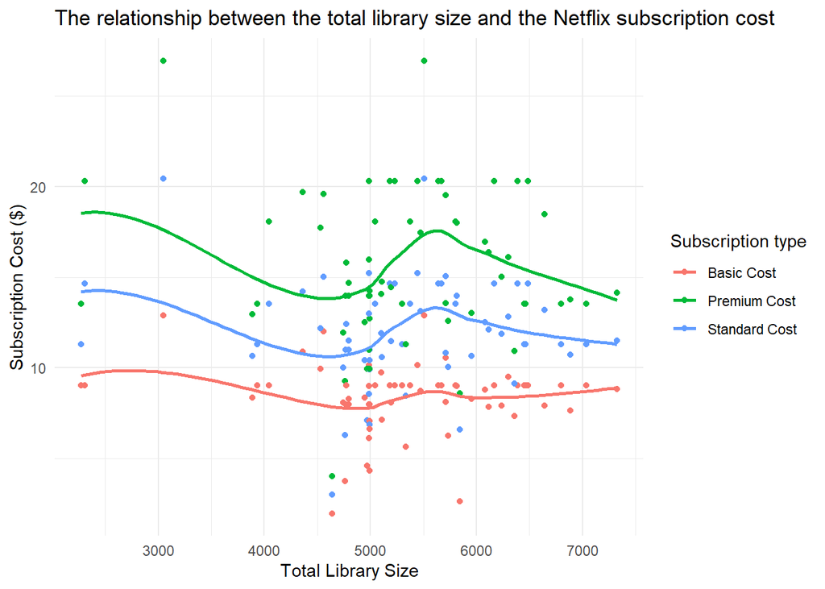

The above graph shows that the relationship between the library size and three subscription costs is neither strictly negative nor positive. Instead, the three curves have a pattern they all seem to follow. The pattern is as follows: as the total library size increase from 2000 to 4500, all the three subscription costs reduce and hit their lowest between 4500 and 5000 library size. Then as the library size increase from 5000 to 5600, the subscription costs increase, and then above the library size of 5600, the subscription costs fall again.

One difference between the three curves is that each curve has a different variance in the cost as the total library size increase. The basic subscription cost has the lowest variance, while the premium subscription has the most variance.

Secondly, we want to explore the relationship between Netflix subscription costs in each country.

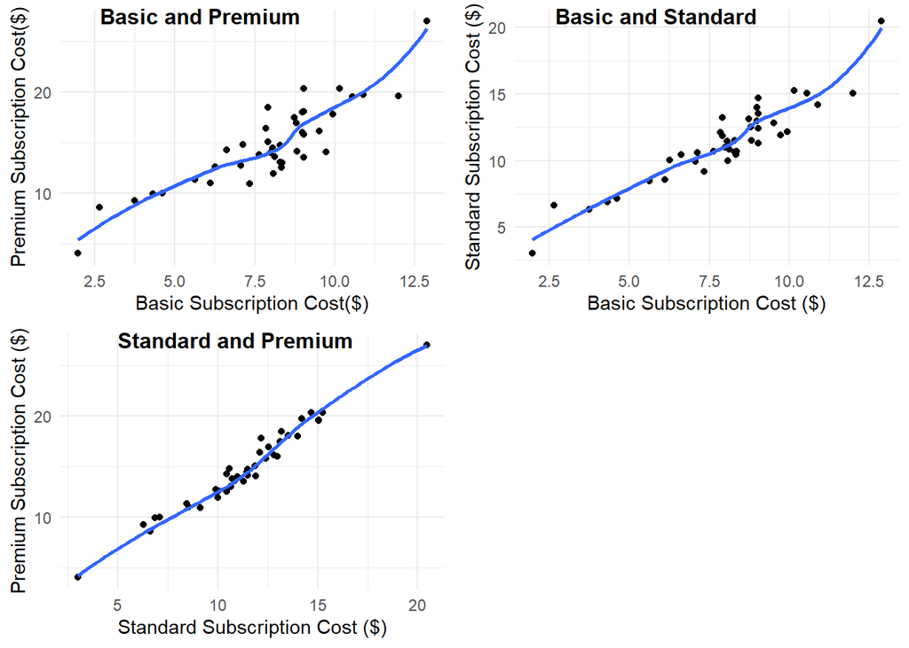

Using the above three graphs to answer our second question, we discovered reasonably strong positive correlations between the three Netflix subscription price points. The strongest correlation was between the standard subscription price and the premium subscription price. The basic price point is correlated with the standard and premium prices, but exhibits more variation. It is important to note that because all prices are set by Netflix, a singular private entity, data entries are not independent.

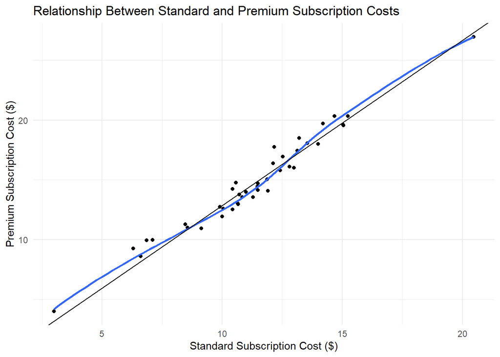

## Discussion

Ultimately, the price of Netflix subscriptions is irregular when comparing between countries on the price they pay for different levels of service, with the size of the library bought having little relation to the cost other countries pay for libraries of varying size. Meanwhile, the price of a premium subscription is highly correlated with the national price for a basic subscription.

Our analysis uses library size as a proxy for its value. While this is the most accessible quantitative metric available to us, it is not necessarily ironclad. It does not capture the value of each movie to consumers, nor does it measure how many of the titles are accessible to each national subscription base (e.g., the language each movie or TV show is in). Many obscure foreign language titles would probably be less valuable than a single blockbuster title. This is not captured by our data.

To advance this research further, we might analyze each subscription price in the context of the average national income, as this is the national economic factor most likely to impact the price consumers are willing to pay for a product.

Ultimately, we conclude that there exists strong evidence that national factors are paramount in determining the price of Netflix subscription. One might expect access to a certain number of movies in Egypt to be just as valuable as access to that same number of movies in Norway, given that it is essentially the same product. Our analysis between countries in terms of price paid for library volume shows this is not the case. However, the price of higher-level subscriptions is strongly correlated with their national basic subscription. Therefore, price comparisons between countries suggest national market distortions, which is supported by comparisons in price within a country which reveal a high degree of conformity when national factors are held constant. This provides greater evidence that national economic factors play a role in the pricing of a highly standardized product: Netflix.

While it is beyond the scope of both our investigation and our data to attribute the difference in amount paid per movie accessed to specific factors, the price of luxury subscriptions is highly correlated with the basic price in that country. So, there is a high degree of conformity within each national pricing plan and differences appear when comparing different countries. This suggests that national economic variation is the reason for variation in the price of Netflix subscriptions. While not having investigated it, it is noticeable that the higher prices are found in Liechtenstein and Switzerland ($12.88 basic subscription) and the lowest prices are found in Turkey and India ($1.97 and $2.64 respectively). The differences between Switzerland and India are manifold, but it is difficult to ignore the differences in wealth between the two countries. Further research might focus on the impact of wealth on prices for different goods or services. It might also seek to investigate the mechanisms by which national wealth has an impact (if any) on prices by contrasting price differences between different groups. This would aid in establishing any potential causal mechanisms for the apparent correlation in national wealth and the price of services, helping account for the deficiencies of only analyzing one kind of service in our current study.

## References

[^1]: https://www.kaggle.com/datasets/prasertk/netflix-subscription-price-in-different-countries
[^2]: https://www.comparitech.com/blog/vpn-privacy/countries-netflix-cost/